# Bilgi Yönetim Sistemleri - Bitirme Projesi Rapor : Mert YILMAZ 200401098 Muhammed TERZİ 200401102 Muhammed Onur ULU 200401118 Süleyman AYTEKİN 180401069

## **Q1: İş probleminin tanımı [10 puan]**

FlavorHub, kullanıcıların yemek tariflerini paylaşabilecekleri ve keşfedebilecekleri etkileşimli bir Wordpress web sitesi işletmektedir. Web sitesi, tavsiye sistemi algoritmalarını kullanarak kişiselleştirilmiş reklamlar üzerinden gelir elde etmektedir. Ancak mevcut gelir modeli, kullanıcı etkileşimini ve reklam gelirlerini maksimize etme konusunda bazı zorluklar yaşamaktadır. Bu raporda, kullanıcı etkileşimini artırarak ve reklam hedeflemeyi iyileştirerek gelirlerin nasıl artırılabileceği üzerinde durulacaktır. BYS (Bilgi Yönetim Sistemi) platformunun gelişmiş veri analitiği ve kullanıcı davranış analizi özellikleri, bu süreci destekleyecektir. Platformun veri analitiği araçları, kullanıcı etkileşim verilerini analiz etmek, kullanıcı segmentasyonu yapmak ve kişiselleştirilmiş tavsiyeleri optimize etmek için kullanılacaktır. Bu özellikler, reklamların daha etkili hedeflenmesini ve kullanıcıların sitede daha fazla vakit geçirmesini sağlayarak gelir artışına katkıda bulunacaktır.

İş veri setimizi değiştirdik. Bunun sebebi, ilk veri setimizin veritabanımızdaki tablolarla uyumlu olmaması sebebiyle daha uygun başka bir veri seti seçtik.

**Platformun İsmi:** Wordpress

**Lisansı:** Telif Hakkı © Wordpress. Tüm hakları saklıdır.

**Kısa Tarihçesi:** Wordpress, bilgi yönetimi ve iletişim ihtiyaçlarını karşılamak üzere özel olarak geliştirilmiş bir içerik yönetim platformudur. 2010 yılında kurulmuş olup, o zamandan beri sürekli olarak güncellenmiş ve geliştirilmiştir.

**Platformun Kullanıcıya Sunduğu Özellikler:**

Kolay ve kullanıcı dostu arayüz. Esnek ve özelleştirilebilir içerik yönetimi. Mobil uyumlu tasarım. SEO dostu yapı. Entegre sosyal medya paylaşımı. Çoklu dil desteği. Güvenlik ve veri koruma özellikleri. Kullanılan Yazılım, Veritabanı ve Diğer Teknolojiler:

**Yazılım:** PHP, JavaScript Veritabanı: MySQL Diğer Teknolojiler: HTML, CSS, jQuery Platformun API’si ve Sunduğu Özelliklerin Listesi:

**Wordpress API:** Kullanıcı yönetimi API. İçerik yönetimi API. Veritabanı entegrasyonu API. Sosyal medya paylaşımı entegrasyonu API. SEO optimizasyonu API. Çoklu dil desteği API. Wordpress’i Seçme Nedenleri: Wordpress’i seçmemizde birkaç temel sebep bulunmaktadır:

**Özel İlgi Alanları:** İletişim ve bilgi yönetimi alanında uzmanlaşmış bir platform arayışındaydık. **Daha Önceki Deneyimler:** Daha önce Wordpress’i kullanarak olumlu deneyimler yaşadık ve platformun güvenilirliği ve esnekliği bizi tekrar tercih etmeye yönlendirdi.

**Sektör Hacmi ve Popülerliği:** Wordpress, sektörde geniş bir kullanıcı kitlesine sahip olup, popülerliği ve yaygınlığıyla güven vermektedir.

**Özelliklerin Zenginliği:** Platformun sunduğu özelliklerin zenginliği, ihtiyaçlarımızı karşılamak için ideal bir çözüm sunmaktadır. Bu nedenlerle Wordpress’i seçerek, iletişim ve bilgi yönetimi alanındaki gereksinimlerimizi en iyi şekilde karşılayacağımıza inanıyoruz.

FlavorHub olarak, BYS (Bilgi Yönetim Sistemi) platformumuz olan Wordpress’ten çeşitli öne çıkan özelliklerden yararlanacağız. Özellikle Wordpress’in esnek ve kullanıcı dostu içerik yönetim sistemi sayesinde, kullanıcıların kolayca yemek tarifleri paylaşmasını ve görsel içerikleri etkileşimli bir şekilde yayınlamasını sağlayacağız. Ayrıca, Wordpress’in geniş eklenti ve tema desteği, kullanıcı deneyimini geliştirmek için özelleştirilebilir çözümler sunmamıza olanak tanıyacak. BYS platformu olarak, Wordpress’in entegre analitik araçlarından da faydalanarak, kullanıcı etkileşim verilerini detaylı bir şekilde izleyecek ve bu verilere dayanarak kullanıcıların davranışlarını anlamlandırıp, kişiselleştirilmiş içerik ve reklam stratejileri oluşturacağız.

## **Q2: İş problemini çözmede kullanılacak data seti [10 puan]**

### Veri Seti Bilgileri:

**Veri Seti Adı:** Food.com Recipes and Interactions

**Veri Seti Adresi:** https://www.kaggle.com/datasets/shuyangli94/food-com-recipes-and-user-interactions

**İçeriği:** Bu veri seti, yemek tarifleri ve kullanıcı yorumlarından oluşmaktadır. Tariflerin yanı sıra, her bir tarif için puanlama ve kullanıcı yorumları da bulunmaktadır.

**Verinin Üretim Yöntemi ve Şartları:** Veri, Food.com platformundan toplanmıştır. Food.com, kullanıcıların yemek tariflerini paylaşabildiği bir platformdur. Veri seti, platformdaki kullanıcılar tarafından paylaşılan tarifler ve bu tariflere yapılan yorumlardan oluşmaktadır.

**Verinin Formatı:** Veri seti CSV (Comma Separated Values) formatında sunulmuştur.

**Boyutu:** Veri seti büyük boyutta olup, yaklaşık olarak 280 MB boyutundadır. Ancak biz Wordpress’e Osetin plugin’i ile verileri girerken sorun yaşadık. Bu sebeple verilerin bir kısmını eledik. Kalan 8404 farklı tarif ve bunlara gelen 43569 değerlendirme var.

Veri setinde yer alan **recipes.csv** dosyasında yer alan sütun bilgileri aşağıda verilmiştir.

- *name:* Bu sütun tarifin adını içerir. Örneğin, “deep fried dessert thingys” veya “easiest ever hollandaise sauce”.
- *recipe_id:* Bu sütun tarifin benzersiz kimlik numarasını içerir. Örneğin, “107699” veya “49262”.
- *minutes:* Bu sütun tarifi hazırlamak için gereken toplam süreyi (dakika cinsinden) belirtir. Örneğin, “20” veya “25” dakika.
- *contributor_id:* Bu sütun tarifi ekleyen kullanıcının kimlik numarasını içerir. Örneğin, “158966” veya “64428”.
- *submitted:* Bu sütun tarifi ekleme tarihini içerir. Örneğin, “2005-01-05” veya “2002-12-19”.
- *tags:* Bu sütun tarife ait etiketleri içerir. Bu etiketler tarifin kategorisini, yapılma süresini, yemeğin türünü vb. belirtir. Örneğin, [‘30-minutes-or-less’, ‘time-to-make’, ’course….
- *nutrition*: Bu sütun besin değerlerini içerir ve yedi farklı besin ögesi hakkında bilgi verir. Örneğin, [1663.3, 221.0, 168.0, 66.0, 19.0, 158.0, 29.0]. Bu değerler sırasıyla kalori, toplam yağ, doymuş yağ, kolesterol, sodyum, karbonhidrat ve protein miktarlarını temsil eder.
- *n_steps*: Bu sütun tarifin kaç adımda tamamlandığını belirtir. Örneğin, “20” veya “7”.
- *steps:* Bu sütun tarifin yapım aşamalarını içerir. Her bir adım bir liste öğesi olarak belirtilir. Örneğin, [’in a large bowl, mix flour, granulated sug….
- *description:* Bu sütun tarifin kısa bir açıklamasını veya tarif hakkında bazı bilgileri içerir. Örneğin, “my mother used to make this for us as a special treat when we were kids”.
- *ingredients:* Bu sütun tarifin malzemelerini içerir. Her bir malzeme bir liste öğesi olarak belirtilir. Örneğin, [‘all-purpose flour’, ‘granulated sugar’, ’bak….
- *n_ingredients:* Bu sütun tarifin içerdiği toplam malzeme sayısını belirtir. Örneğin, “13” veya “5”.

Veri setinde yer alan **RAW_interactions.csv** dosyasında yer alan sütun bilgileri aşağıda verilmiştir.

Veri seti üzerinde şu değişiklikleri yaptık:

1. recipes.csv dosyasındaki description sütununda 231 adet boş veri kümesini veritabanına yükleyemediğimiz için boş veri kümelerini boşluk karakteriyle (” “) doldurduk.
2. interactions.csv dosyasındaki “review” sütunundaki 8 adet boş veri kümesini veritabanına yükleyemediğimiz için boş veri kümelerini boşluk karakteriyle (” “) doldurduk.

## **Q3: Veri seti keşifsel analizi [20 puan]**

Veri setinizde bulunan interactions.csv dosyasındaki “user_id”, “recipe_id”, “rating” ve “review” sütunları önemlidir. İşte bu sütunların önemini açıklayan birkaç nokta:

1. **user_id**: Her etkileşim için kullanıcı kimliğini belirtir. Kullanıcılara kişiselleştirilmiş reklam sunabilmemize olanak sağlar.
2. **recipe_id**: Etkileşimin hangi tarife ait olduğunu belirtir.
3. **rating**: Kullanıcıların tariflere verdikleri puanı belirtir. Bu, tariflerin genel memnuniyet seviyesini belirlemek ve popüler tarifleri tanımlamak için önemlidir.
4. **review**: Kullanıcıların tarifler hakkındaki yorumlarını içerir. Bu yorumlar, tariflerin nasıl geliştirilebileceği, hangi özelliklerin beğenildiği veya beğenilmediği gibi değerli içgörüler sağlayabilir.

Bu sütunlar, kullanıcıların davranışlarını, tercihlerini ve geri bildirimlerini anlamak için temel bilgiler sağlar ve projenizin amacına uygun analizler yapmanızı sağlar.

1. **description:** Bu sütun tarifin kısa bir açıklamasını veya tarif hakkında bazı bilgileri içerir. Metinsel veri analizi yapacağımız için en önemli sütunumuz budur.
2. **recipe_id:** Bu sütun, incelemesi yapılan tarifin benzersiz kimlik numarasını içerir.

**Kütüphanelerin import edilmesi**

**Verisetlerininin okunması**

**df1 dataframe’i tariflere gelen değerlendirmeleri içeriyor**

**df2 dataframe’i tarifleri ve bu tariflerle ilgili diğer verileri içeriyor**

**verisetleri için ilk shape bilgilerinin görüntülenmesi**

```
## [1] 100000      5
```

```
## [1] 100000     12
```

**verisetinin boyutu büyük olduğu için yapılacak veri manipülasyonu işlemleri, uzun sürecek. Bu durumu engellemek için verisetlerinin boyutunu küçülteceğiz** **df2 değişkenindeki post id sütun ismini df1’de karşılık geldiği recipe_id sütun ismiyle aynı yapalım.**

**Eşit olmayan recipe_id’lere sahip satırların filtrelenmesi ve güncellenmesi**

**boyutu küçültüldükten sonra verisetlerinin son halleri**

```
## [1] 43569     5
```

```
## [1] 8404   12
```

| name | recipe_id | minutes | contributor_id | submitted | tags | nutrition | n_steps | steps | description | ingredients | n_ingredients |
| --- | --- | --- | --- | --- | --- | --- | --- | --- | --- | --- | --- |
| deep fried dessert thingys | 107699 | 20 | 158966 | 2005-01-05 | ['30-minutes-or-less', 'time-to-make', 'course', 'preparation', 'occasion', 'low-protein', 'desserts', 'deep-fry', 'stove-top', 'dietary', 'high-calcium', 'high-in-something', 'low-in-something', 'tas… | [1663.3, 221.0, 168.0, 66.0, 19.0, 158.0, 29.0] | 20 | ['in a large bowl , mix flour , granulated sugar , baking powder and salt', 'make a well in the center of the flour mixture , and pour in milk , vanilla , egg and 2 tablespoons oil', 'mix until smooth… | my mother used to make this for us as a special treat. i don't know where she got this recipe or what it is called (hence the title). my husband loves this and encouraged me to submit it. this recipe … | ['all-purpose flour', 'granulated sugar', 'baking powder', 'salt', 'vanilla extract', 'egg', 'milk', 'vegetable oil', 'bread', 'brown sugar', 'ground cinnamon', 'butter', 'powdered sugar'] | 13 |
| easiest ever hollandaise sauce | 49262 | 25 | 64428 | 2002-12-19 | ['30-minutes-or-less', 'time-to-make', 'course', 'main-ingredient', 'preparation', 'very-low-carbs', 'sauces', 'condiments-etc', 'eggs-dairy', 'eggs', 'stove-top', 'dietary', 'low-carb', 'savory-sauce… | [1290.4, 213.0, 4.0, 53.0, 22.0, 417.0, 1.0] | 7 | ['cut the butter into several pieces and bring to room temperature', 'in the top of a double boiler , combine egg yolks , lemon juice , salt and pepper', 'add a piece of butter', 'cook , stirring stea… | the secret to this easy hollandaise sauce is in separating the egg yolks. remove all the egg whites, as they can thin the sauce. also, it is best prepared in a double boiler to prevent overheating. se… | ['butter', 'lemon, juice of', 'salt', 'white pepper', 'egg yolks'] | 5 |
| i yam what i yam muffins | 93958 | 45 | 133174 | 2004-06-22 | ['60-minutes-or-less', 'time-to-make', 'course', 'preparation', 'breads', 'muffins', 'quick-breads'] | [171.8, 9.0, 28.0, 10.0, 8.0, 4.0, 8.0] | 10 | ['preheat oven to 375 degrees', 'spray muffin tin with non-stick cooking spray and set aside', 'place the raisins in a small bowl and pour the 1 / 4 cup boiling water over them', 'cover and set aside … | these muffins may have slightly different ingredients but the end result is a wonderful rich, moist muffin. the sugar sprinkled on top before cooking gives a slightly sweet crunch and cracked glazed a… | ['all-purpose flour', 'buckwheat flour', 'unsweetened cocoa', 'baking powder', 'baking soda', 'salt', 'ground cinnamon', 'ground cloves', 'sorghum', 'eggs', 'yam', 'low-fat buttermilk', 'orange rind',… | 18 |
| immoral sandwich filling loose meat | 58224 | 35 | 37183 | 2003-04-04 | ['60-minutes-or-less', 'time-to-make', 'course', 'main-ingredient', 'preparation', 'for-large-groups', 'very-low-carbs', 'lunch', 'main-dish', 'beef', 'easy', 'stove-top', 'dietary', 'sandwiches', 'lo… | [223.2, 22.0, 4.0, 7.0, 35.0, 30.0, 0.0] | 6 | ['brown the meat & drain fat', 'stir in sugar , mustard , beer , cayenne , garlic and salt & pepper to taste', 'simmer until liquid has mostly cooked away', 'lay slices of cheese over top of meat , th… | just the thing for a day when you're wanton something delicious, and a hamburger patty is just too restrictive. loosen up your inhibitions and pile some loose meat on a bun. wicked over hot, whipped p… | ['ground beef', 'sugar', 'prepared yellow mustard', 'beer', 'cayenne', 'garlic', 'salt & pepper', 'american cheese'] | 8 |
| killer lasagna | 53402 | 90 | 60512 | 2003-02-04 | ['weeknight', 'time-to-make', 'course', 'main-ingredient', 'cuisine', 'preparation', 'occasion', 'casseroles', 'main-dish', 'pasta', 'oven', 'european', 'potluck', 'dinner-party', 'heirloom-historical… | [370.5, 38.0, 21.0, 57.0, 53.0, 64.0, 3.0] | 13 | ['brown the sausage and ground meat and drain all the fat', 'add all the other ingredients for the meat filling and simmer on the stove , uncovered , for about 1 / 2 hour', 'i usually add a bay leaf o… | this was originally my mom's recipe and used to be a favorite when we were kids. i always requested it for my birthday dinner. | ['italian sausage', 'ground beef', 'garlic', 'dried basil', 'salt', 'whole tomato', 'tomato paste', 'ricotta cheese', 'cottage cheese', 'parmesan cheese', 'parsley flakes', 'eggs', 'ground black peppe… | 15 |
| mexican pasta | 60219 | 25 | 76846 | 2003-04-18 | ['30-minutes-or-less', 'time-to-make', 'course', 'main-ingredient', 'cuisine', 'preparation', 'north-american', 'healthy', 'side-dishes', 'pasta', 'mexican', 'easy', 'low-fat', 'dietary', 'inexpensive… | [325.3, 10.0, 11.0, 39.0, 26.0, 17.0, 17.0] | 5 | ['boil pasta as directed on package', 'drain and put in large serving bowl', 'mix picante sauce , milk , and cheese soup in a smaller bowl until creamy', 'heat in microwave until warm', 'mix sauce and… | made this as a side dish for mexican meatballs (#58471)because my oldest won't do rice. even she liked it! | ['fettuccine pasta', 'cheddar cheese soup', 'milk', 'picante sauce', 'black olives', 'jalapeno'] | 6 |

| user_id | recipe_id | date | rating | review |
| --- | --- | --- | --- | --- |
| 8937 | 44394 | 2002-12-01 | 4 | This worked very well and is EASY. I used not quite a whole package (10oz) of white chips. Great! |
| 126440 | 85009 | 2010-02-27 | 5 | I made the Mexican topping and took it to bunko. Everyone loved it. |
| 57222 | 85009 | 2011-10-01 | 5 | Made the cheddar bacon topping, adding a sprinkling of black pepper. Yum! |
| 202555 | 225241 | 2007-06-20 | 5 | My husband has just found out that he had to cut down on fat. He..like a lot of Okies is a solid meat and potato guy. \r\nIt has been really hard to find things that he likes to eat but this recipe fi… |
| 353579 | 225241 | 2007-08-14 | 5 | Very good, made with ingredients I usually have. I didn't want to heat up my kitchen, so I did the final cooking in the microwave, which worked just fine. Thanks for posting! |
| 635209 | 225241 | 2007-11-06 | 4 | Thought this was a great Core recipe. My 79-year-old mom loved it too. I did multiply the proportions x 3 or 4 so I could use whole cans of beans/Ro-tel tomatoes. Also just added whole egg to the topp… |

```
##     user_id            recipe_id           date                rating
##  Min.   :1.533e+03   Min.   :    39   Min.   :2000-11-20   Min.   :0.000
##  1st Qu.:1.307e+05   1st Qu.: 43817   1st Qu.:2006-12-26   1st Qu.:4.000
##  Median :3.167e+05   Median :105773   Median :2008-11-05   Median :5.000
##  Mean   :1.328e+08   Mean   :149235   Mean   :2009-03-10   Mean   :4.425
##  3rd Qu.:7.582e+05   3rd Qu.:222563   3rd Qu.:2010-12-31   3rd Qu.:5.000
##  Max.   :2.002e+09   Max.   :537241   Max.   :2018-12-18   Max.   :5.000
##     review
##  Length:43569
##  Class :character
##  Mode  :character
##
##
##
```

**df2 özet istatistikleri görüntüleyelim.**

```
##      name             recipe_id         minutes         contributor_id
##  Length:8404        Min.   :    39   Min.   :    0.00   Min.   :2.700e+01
##  Class :character   1st Qu.: 87285   1st Qu.:   20.00   1st Qu.:5.312e+04
##  Mode  :character   Median :192887   Median :   40.00   Median :1.640e+05
##                     Mean   :212701   Mean   :   92.09   Mean   :5.011e+06
##                     3rd Qu.:325881   3rd Qu.:   70.00   3rd Qu.:3.790e+05
##                     Max.   :537241   Max.   :21630.00   Max.   :2.002e+09
##    submitted              tags            nutrition            n_steps
##  Min.   :1999-08-09   Length:8404        Length:8404        Min.   : 1.00
##  1st Qu.:2004-03-22   Class :character   Class :character   1st Qu.: 6.00
##  Median :2006-10-30   Mode  :character   Mode  :character   Median : 8.00
##  Mean   :2006-08-29                                         Mean   : 9.63
##  3rd Qu.:2008-09-19                                         3rd Qu.:12.00
##  Max.   :2018-10-18                                         Max.   :90.00
##     steps           description        ingredients        n_ingredients
##  Length:8404        Length:8404        Length:8404        Min.   : 2.000
##  Class :character   Class :character   Class :character   1st Qu.: 6.000
##  Mode  :character   Mode  :character   Mode  :character   Median : 9.000
##                                                           Mean   : 8.979
##                                                           3rd Qu.:11.000
##                                                           Max.   :30.000
```

**verisetlerindeki NaN veri sayıları**

```
## [1] 8
```

```
## [1] 231
```

**Boş değer içeren sütunları görüntüleyin**

```
##        column na_count na_percentage
## review review        8    0.01836168
```

```
##                 column2 na_count2 na_percentage2
## description description       231       2.748691
```

**Boş değer içeren sütunların görüntülenmesi**

**df1 verisetindeki ‘review’ sütununda 8 adet boş değer var**

**df2 verisetindeki ‘description’ sütununda 231 adet boş değer var**

```
## [1] 0
```

```
## [1] 0
```

**df1 için histogram (rating dağılımı)**

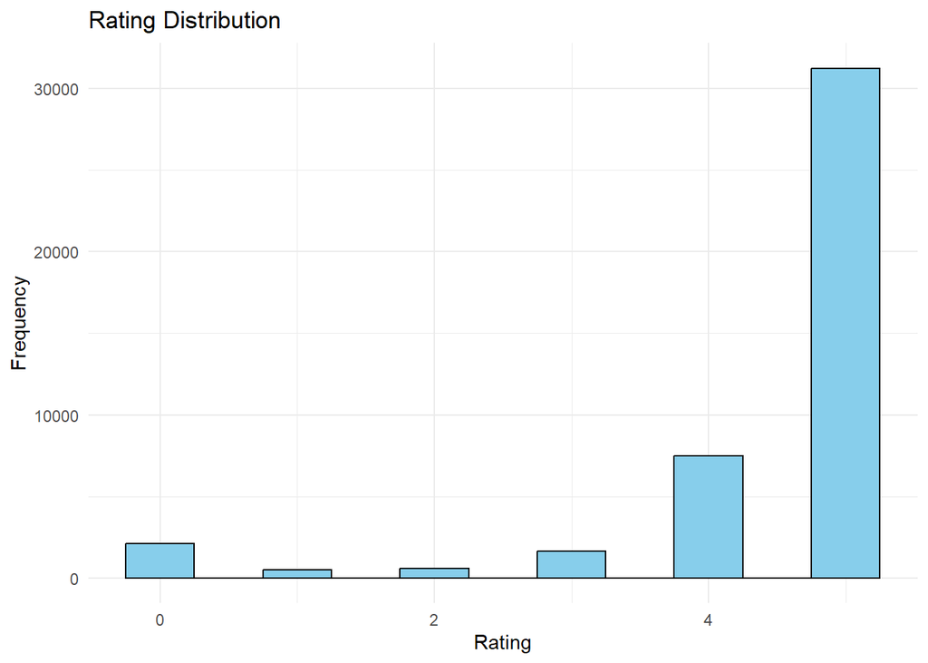

**df2 için histogram veya kutu grafiği (malzeme sayısı dağılımı)**

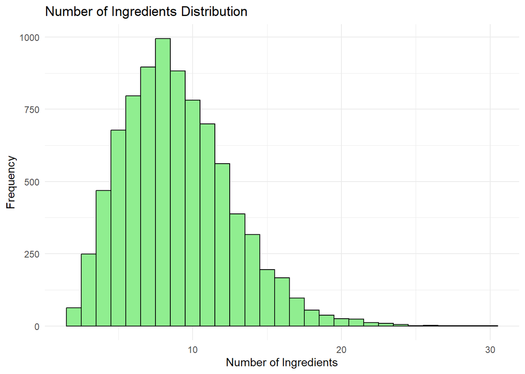

*Grafiğe göre tariflerde ortalama 8 ile 10 arasında malzeme kullanıldığı görülmektedir.*

## **Q4: Veri setinin BYS platformuna ihtali [20 puan]**

Veri setimizi kullanıcıların sisteme doğrudan veri girişi yaptığı şekilde yükleyemediğimiz için **wp_all_import** eklentisini kullanarak yemek tariflerini post olarak girebildik ancak tariflere gereken yorumları ithal edemedik. Tariflerin eklenmesi Q6’da videoda detaylıca gösterilecektir.